# Intro to Stats and Regression from a Spreadsheet using R with a little bit of fun using units

### Creating our linear model and “calibrating” it

Not so good a correlation there…

But let’s move on and create a regression model from this.

For the regression formula

$Strengh = {\alpha_0}+{\alpha_1}\ concrete$

the “prototype” (formula) for the function is written as …

“Y ~ X” (with the y-intercept implicit in the formula… you don’t put it in but it’ll be there when you’re done.)

The above syntax is works like this….

Dependant Variable [~ is a function of ] Independant Variable [and any other parameter you need gets added with a plus]

If this were a $\hat{y}(x)={\alpha_0}+{\alpha_0}\ x^2$, then the prototype for the function would be y~[x^2]

This will hopefully make more sense as we continue!

*(lm and similar linear regression functions don’t play well with units.)*

```r
linear_model.S_v_c =  lm(formula = Compressive_Strength_28dy ~ Cement, # your formula y ~ x
                         data    = concrete)                           # the data frame
```

Let’s see what we have… This summary command will provide the details of the lm() function’s important results

The Standard Error of the Estimate is there (Residual Standard Error) as is the Coefficient of Determination (Multiple R-squared)

We’ll talk about a few of the other features when we do the larger multivariate regression

```r
 summary(object = linear_model.S_v_c)
```

```
##
## Call:
## lm(formula = Compressive_Strength_28dy ~ Cement, data = concrete)
##
## Residuals:
##      Min       1Q   Median       3Q      Max
## -15.1335  -5.3126   0.8321   5.1553  17.9680
##
## Coefficients:
##              Estimate Std. Error t value Pr(>|t|)
## (Intercept) 25.856758   2.150223  12.025  < 2e-16 ***
## Cement       0.044293   0.008851   5.004 2.38e-06 ***
## ---
## Signif. codes:  0 '***' 0.001 '**' 0.01 '*' 0.05 '.' 0.1 ' ' 1
##
## Residual standard error: 7.051 on 101 degrees of freedom
## Multiple R-squared:  0.1987, Adjusted R-squared:  0.1907
## F-statistic: 25.04 on 1 and 101 DF,  p-value: 2.379e-06
```

In the above output, the asterisk identify the most signiicant independant variables. Here it’s trivial even though this is a terrible relationship between cement and strength. Later we will use all of our available independant variables and the use of these asteriks will become more important.

Now let’s make a pair of 95% confidence limits

Create a simple linear array to stretch from our min to max dependent values

I tend to overcompensate here and make a BIG array with the sequence (seq) function

Here I am making a variable called “newx” that will represent 501 values of Cement going from 0 to 500 kg m-3.

```r
newx <- seq(from       =   0,  # start for a sequence
            to         = 500,  # end for a sequence
            length.out = 501)  # number of elements in a sequence
```

And here we create an array of the confidence limits using this “newx” field

(Note that use can use this function “predict” to do both prediction and confidence limits and also remember that prediction limits should ONLY be used when your original data samples conform to a normal distribution – which often isn’t the case.)

```r
conf.S_v_c <- predict(object   = linear_model.S_v_c,     # your regression model
                      interval = c("confidence"),        # confidence or prediction intervals
                      level    = 0.95,                   # 1-alpha (here it's a 95% CI)
                      newdata  = data.frame(Cement=newx) # swapping out of new indep variables
                      )
```

The resulting array, conf, will have three columns: the original linear regression using our newx as the independent value and the + & - CI’s

```r
# this will make a pretty print of our output here.
data.frame(conf.S_v_c)
```

|  | fit | lwr | upr |
| --- | --- | --- | --- |
| 1 | 25.85676 | 21.59129 | 30.12222 |
| 2 | 25.90105 | 21.65220 | 30.14990 |
| 3 | 25.94534 | 21.71310 | 30.17759 |
| 4 | 25.98964 | 21.77399 | 30.20528 |
| 5 | 26.03393 | 21.83487 | 30.23299 |
| 6 | 26.07822 | 21.89575 | 30.26070 |
| 7 | 26.12251 | 21.95661 | 30.28842 |
| 8 | 26.16681 | 22.01747 | 30.31614 |
| 9 | 26.21110 | 22.07832 | 30.34388 |
| 10 | 26.25539 | 22.13916 | 30.37162 |

[output cut: 491 more lines]

So let’s replot our relationship…

…our regression

and finally our lower than upper confidence limits…

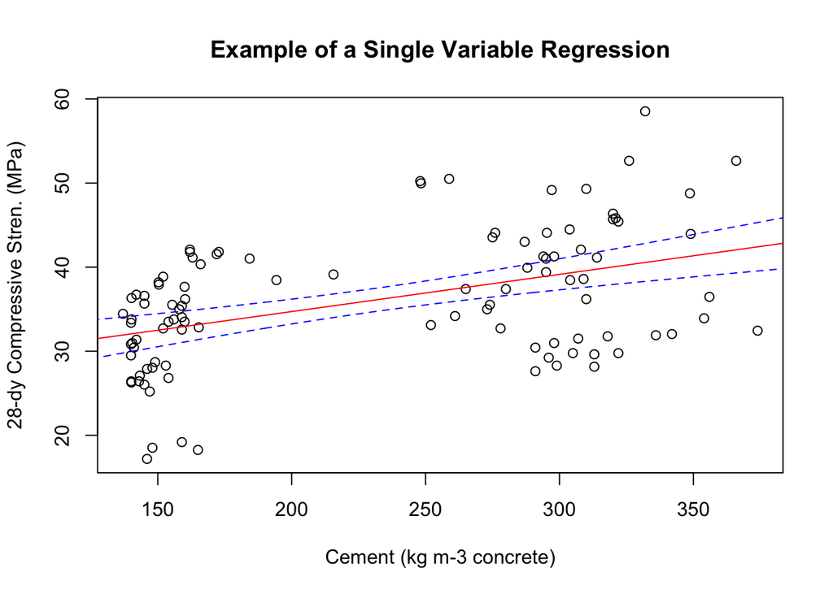

```r
# Now we can plot

plot(x    = concrete$Cement,                          # x-values (the $ lets us reach into
     y    = concrete$Compressive_Strength_28dy,            # y-values     the data frame)
     main = "Example of a Single Variable Regression", # main title string
     xlab = "Cement (kg m-3 concrete)",                # x-labels
     ylab = "28-dy Compressive Stren. (MPa)"           # y-labels
     )

# And here we can plot the regression line

abline(reg = linear_model.S_v_c,  # put the regression model information here
       col = "red"                # color it red
       )

# And here we create an array of the confidence limits using this "newx" field

lines(x   = newx,           # the x data
      y   = conf.S_v_c[,2], # the y data (the low-end confidence limit)
      col = "blue",         # make the line blue
      lty = 2)              # use a dashed line

lines(x   = newx,           # the x data
      y   = conf.S_v_c[,3], # the y data (the high-end confidence limit)
      col = "blue",         # make the line blue
      lty = 2)              # use a dashed line
```

Looks pretty good! (well the graph does.. not necessarily the quality of the regression)

(FYI, Tidyverse’s toolkit can do this with less effort. If you want to go hardcore with R it may be a good idea to look at the version of this Notebook adapted for the tidyverse.)

And now we’re going to do something about that!

We’re now going to use not just one independent variable… but all 7 of them!

The good news is that it follows the same form as the simple linear regression. This time we string along all of our independent variables with in our formula prototype.

```r
linear_model.S_v_all <- lm(data    = concrete,                              # your data frame
                           formula = Compressive_Strength_28dy ~ Cement +  # your formula
                                                                 Slag +
                                                                 Fly_Ash +
                                                                 Water +
                                                                 Superplasticizer +
                                                                 Fine_Aggregates +
                                                                 Coarse_Aggregates
                           )
```

And here are these results…

```r
summary(object = linear_model.S_v_all)
```

```
##
## Call:
## lm(formula = Compressive_Strength_28dy ~ Cement + Slag + Fly_Ash +
##     Water + Superplasticizer + Fine_Aggregates + Coarse_Aggregates,
##     data = concrete)
##
## Residuals:
##     Min      1Q  Median      3Q     Max
## -5.8411 -1.7063 -0.2831  1.2986  7.9424
##
## Coefficients:
##                    Estimate Std. Error t value Pr(>|t|)
## (Intercept)       139.78150   71.10128   1.966  0.05222 .
## Cement              0.06141    0.02282   2.691  0.00842 **
## Slag               -0.02971    0.03176  -0.935  0.35200
## Fly_Ash             0.05053    0.02316   2.182  0.03159 *
## Water              -0.23270    0.07166  -3.247  0.00161 **
## Superplasticizer    0.10315    0.13459   0.766  0.44532
## Fine_Aggregates    -0.03908    0.02882  -1.356  0.17833
## Coarse_Aggregates  -0.05562    0.02744  -2.027  0.04546 *
## ---
## Signif. codes:  0 '***' 0.001 '**' 0.01 '*' 0.05 '.' 0.1 ' ' 1
##
## Residual standard error: 2.609 on 95 degrees of freedom
## Multiple R-squared:  0.8968, Adjusted R-squared:  0.8892
## F-statistic:   118 on 7 and 95 DF,  p-value: < 2.2e-16
```

Our regression coefficients are still here under the “Estimate” column as are our Standard Error of our Estimate and our Coeff of Determination.

Also we can now take a good look at those asterisks at the end of line with the parameter coefficients. These can explain which independent variables do the heaviest lifting in our regression. The more asterisks, the more important the dependent variable is to the larger multivariate regression. Here, we can see that the Cement and Water are doing most of the “work” in fitting our suite of independent variables to our dependent variable of Compressive Strength.

Finally there is the P parameter for which the smaller it is, the better we can say that the relationship that we’ve made with our regression represents our dependent variable.

Now… on to looking at our results.

Here is where viewing the results of the regression is tricky.

We have 7 independent variables but we’d like to see the impact of the fit if all 7 variables on our strength

When I do this I like to plot the true y value against my regression y(x1,x2,x3,..)

So to do this I will take the fitted values of y and plot them against the original values of y

Getting the fitted values is easy.

I’m using the fitted function but you can also use the predict function from earlier with the fitted function.

```r
fitted.S_v_all <- fitted(object = linear_model.S_v_all)
```

The other thing is to now do a second regression (ok a third in this entire demo…)

Here we will just regress y(x1,x2…) against y.

```r
linear_model.S_v_Sofall <- lm(formula = fitted.S_v_all ~ concrete$Compressive_Strength_28dy)

summary(object = linear_model.S_v_Sofall)
```

```
##
## Call:
## lm(formula = fitted.S_v_all ~ concrete$Compressive_Strength_28dy)
##
## Residuals:
##     Min      1Q  Median      3Q     Max
## -6.7870 -1.6428  0.2609  1.6482  4.9775
##
## Coefficients:
##                                    Estimate Std. Error t value Pr(>|t|)
## (Intercept)                         3.71791    1.11603   3.331  0.00121
## concrete$Compressive_Strength_28dy  0.89684    0.03027  29.632  < 2e-16
##
## (Intercept)                        **
## concrete$Compressive_Strength_28dy ***
## ---
## Signif. codes:  0 '***' 0.001 '**' 0.01 '*' 0.05 '.' 0.1 ' ' 1
##
## Residual standard error: 2.396 on 101 degrees of freedom
## Multiple R-squared:  0.8968, Adjusted R-squared:  0.8958
## F-statistic:   878 on 1 and 101 DF,  p-value: < 2.2e-16
```

And you’ll see that they have the same correlation coefficient as the earlier multivariate regression

And now, let’s close this exercize and plot up our multivariate regression.

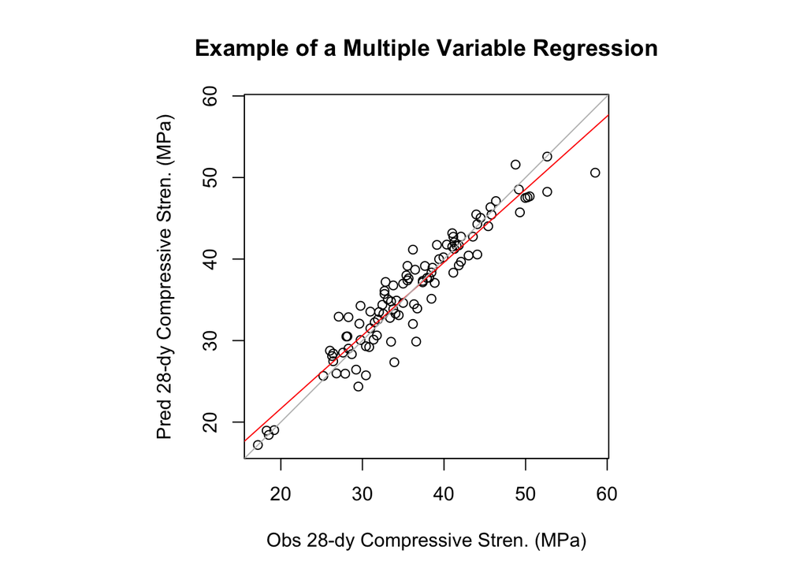

```r
# first we need to set a specific graphics parameter to set our plot shape.
#   "s" makes a square, "m" is the default which maximizes the plot region.

par(pty = "s") # this makes the plot square
               # (I like square plots when I plot "apples against apples")

# now a simple x-y scatterplot as before but with both axes having
#   the same range...

plot(x    = concrete$Compressive_Strength_28dy,          # x-values
     y    = fitted.S_v_all,                              # y-values
     main = "Example of a Multiple Variable Regression", # title string
     xlab = "Obs 28-dy Compressive Stren. (MPa)",        # x-label
     ylab = "Pred 28-dy Compressive Stren. (MPa)",       # y-label
     xlim = c(min(concrete$Compressive_Strength_28dy,    # limits on the axes
                  fitted.S_v_all),  # x-axis range
              max(concrete$Compressive_Strength_28dy,
                  fitted.S_v_all)),
     ylim = c(min(concrete$Compressive_Strength_28dy,
                  fitted.S_v_all),  # y-axis range
              max(concrete$Compressive_Strength_28dy,
                  fitted.S_v_all)),
     asp = 1                                             # aspect ratio between
     )

# plot the linear regression line

abline(reg = linear_model.S_v_Sofall,  # put the regression output here
       col = "red"                     # color it red
       )

# and we can also plot a simple one:to:one line.

abline(a   = 0,     # y-intercept
       b   = 1,     # slope
       col = "grey" # color it grey
       )
```

And here we have a nice plot showing our true vs predicted values.

While here, we can do some general error metrics that may be useful..

First, the Bias… (if we are too high or too low)

$BIAS = \frac{1}{N} \sum_{i=1}^{n} (est_i-true_i) = \overline{(est-true)}$

```r
bias = mean(fitted.S_v_all - concrete$Compressive_Strength_28dy)

print("BIAS")
```

```
## [1] "BIAS"
```

```r
print(bias)
```

```
## [1] -1.3802e-16
```

The root mean squared error (RMSE) thought he standard error of the estmate is technically the one we use here. RMSE remains a common error metric though…

$RMSE = \sqrt{ \frac{1}{N} \sum_{i=1}^{n} (est_i-true_i)^2 } = \sqrt{\overline{(est-true)^2}}$

```r
rmse = sqrt(mean( (fitted.S_v_all - concrete$Compressive_Strength_28dy)^2)  )

print("RMSE")
```

```
## [1] "RMSE"
```

```r
print(rmse)
```

```
## [1] 2.505303
```

And finally our correlation coefficient (which is basically our coefficient of determination before the “R” is “squared”)

```r
r = cor(x = fitted.S_v_all,                     # the x-value
        y = concrete$Compressive_Strength_28dy, # the y-value
        method = "pearson"                      # method of correlation
        )

print("correlation coefficient")
```

```
## [1] "correlation coefficient"
```

```r
print(r)
```

```
## [1] 0.9470151
```

```r
print("coefficient of determination")
```

```
## [1] "coefficient of determination"
```

```r
print(r^2)
```

```
## [1] 0.8968376
```

And with that, we’re done…

But now an example of tiyversing…

# Annex: Playing with Tidyverse.

[Tidyverse](https://www.tidyverse.org) is a “new thing” and is framed as a new way to work with data, visualize data and communicate with it.

Some elements of “tidying” *do* have a steep learning curve but once you see the method of the madness it does start to make working with large datasets easier.

While the basic statistics courses at Mines don’t use a lot of Tidyverse (if at all), if you work with R a lot and work with people who work with R a lot, inevitably this is a bridge you will cross.

To install most of tidyverse can simply install “tidyverse” and load it as a library. This will handle much of the basic data handling.

Let’s start with a “simple example” of plotting the histogram of cement.

(Full Disclosure, this really confused me when starting with these new ways of attacking data)

First, don’t forget to load the main library set.

```r
library(package = "tidyverse")
```

Now I’m going to do this one tiny step at a time until we get to a viable product.